# Методы организации безопасности в операционных системах

Операционные системы

Симонова Полина Игоревна

Российский университет дружбы народов, Москва, Россия

31.03.2025

# Информация

## Докладчик

- Симонова Полина Игоревна
- студент группы НКАбд-04-24
- Российский университет дружбы народов
- 1132246738@rudn.ru
- https://o5o6am.github.io/

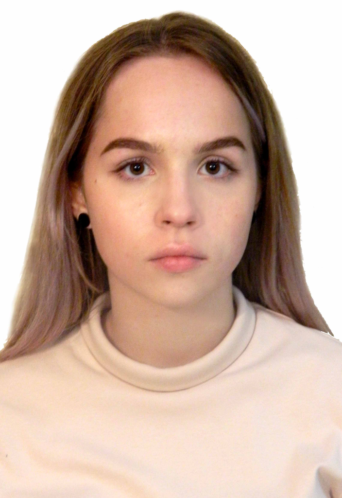

## Актуальность

Актуальность моего доклада обусловлена ростом киберугроз и необходимостью защиты конфиденциальной информации в корпоративных и частных системах.

## Объект и предмет исследования

- Объектом исследования являются операционные системы и их безопасность
- Предметом исследования являются различные методы и механизмы обеспечения безопасности в ОС

## Цель работы

- Изучить основные методы обеспечения безопасности операционных систем и способы их применения в современных ОС (Windows, macOS, Linux)

## Задачи

- Изучить механизмы аутентификации и авторизации, их роль в защите данных;
- Рассмотреть методы защиты памяти и процессов от вредносного воздействия;
- Изучить межсетевые экраны и системы обнаружения вторжений, их роль в обеспечении безопасности.

## Теоретическое введение

Безопасность ОС — критически важный аспект, поскольку уязвимости могут привести к утечке данных, несанкционированному доступу и другим киберугрозам.

## Аутентификация и авторизация

Аутентификация — процедура проверки подлинности

Методы аутентификации

| Метод | Примеры | Надежность |
| --- | --- | --- |
| Пароли | Логин/пароль | Низкая |
| 2FA | SMS, Google Auth | Средняя |
| Биометрия | Face ID, отпечаток | Высокая |
| Сертификаты | PKI, Smart-карты | Очень высокая |

## Авторизация

Авторизация - предоставление прав доступа.

Основные методы:

- Дискреционное управление доступом (DAC) — владелец ресурса сам назначает права (например, в Linux через chmod).
- Мандатное управление доступом (MAC) — строгие правила, заданные администратором (используется в SELinux).
- Ролевое управление доступом (RBAC) — права назначаются ролям, а не пользователям.

## Разделение адресных пространств

ОС изолирует процессы, предотвращая их вмешательство в работу друг друга.

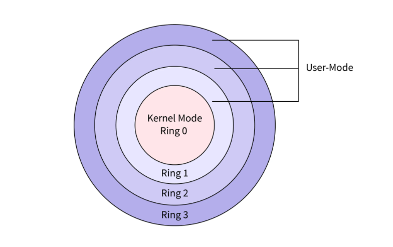

Сравнение Kernel Mode и User Mode

## Шифрование файловых систем

Шифрование — это метод защиты информации путём преобразования её в зашифрованный вид.

- BitLocker - программа для полного шифрования диска, позволяющая создать диск BitLocker

[figure not shown]

BitLocker

- EFS (Encrypting File System)

## Защита сетевого трафика

- VPN
- Защищённый туннель для удалённого доступа
- SSL (Secure Sockets Layer)/TLS (Transport Level Security)
- Шифрование веб-трафика (HTTPS)

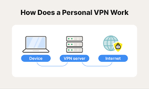

Принцип работы VPN

## Межсетевые экраны

Файрволы (Firewalls) — это программное или аппаратное устройство, которое контролирует и фильтрует сетевой трафик на основе заданных правил.

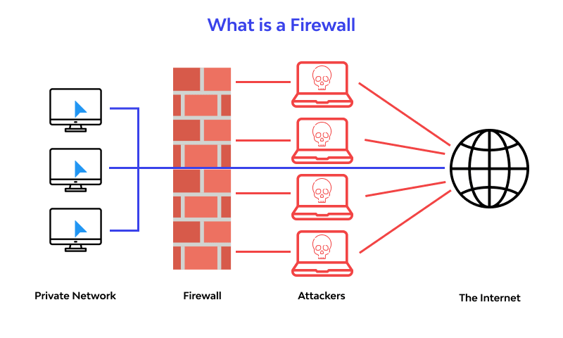

Принцип работы межсетевого экрана

## Системы обнаружения и предотвращения вторжений (IDS/IPS)

IDS/IPS - используются для выявления и предотвращения попыток несанкционированного проникновения во внутренние сети

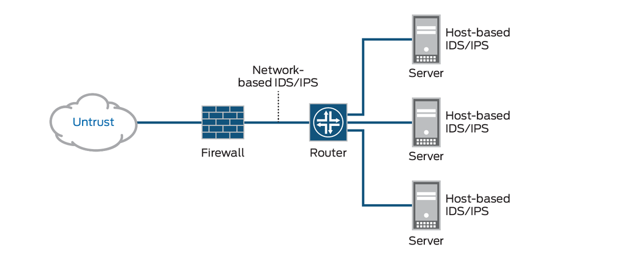

Принцип работы IDS и IPS

## Обновления и мониторинг безопасности

Сравнение систем обновления в ОС

| Критерий | Windows | Linux (Ubuntu) | macOS |
| --- | --- | --- | --- |
| Менеджер обновлений | Windows Update | apt (APT) | Software Update |
| Частота обновлений | Ежемесячно (Patch Tuesday) | По мере выхода | Ежеквартально |
| Критические исправления | Автоматически через WU | Вручную/авто через репозитории | С задержкой 1-2 недели |
| Поддержка EOL* | 5-10 лет | До 10 лет (LTS) | ~7 лет |
| Риски | “Сломанные” обновления | Конфликты зависимостей | Задержки безопасности |

## Заключение

Безопасность операционных систем обеспечивается комплексом методов: от аутентификации и шифрования до защиты памяти и сетевой безопасности. Постоянное развитие угроз требует регулярного обновления защитных механизмов

## Выводы

Я изучила механизмы аутентификации и авторизации, методы защиты памяти и процессов от вредоносного воздействия и их роль в защите данных.